# R Notebook

Growth chamber well water experimen. Peanut were inoculated with five different fungal isolates from Alabama cotton fields (Mortierellas and Linnemannia) and from the Old Rotation (P. citrinum)

here we analyze and visualize the growth chamber results (Phi2, shoot and root biomass)

Loading Packages and dependencies

```r
library(ggplot2)
library(tidyverse)
library(ggpubr)
library(emmeans)
library(multcomp)
library(lsmeans)
library(lme4)
library("lmerTest")
```

Palettes

```r
cbbPalette <- c("#000000", "#E69F00", "#56B4E9", "#009E73", "#F0E442", "#0072B2", "#D55E00", "#CC79A7")
fungi.colors <- c("#c6dbef","#9ecae1","#6baed6","#3182bd","#08519c",
                           "#c7e9c0", "#a1d99b", "#74c476", "#41ab5d", "#238b45", "#005a32",
                           "#fdd0a2", "#fdae6b", "#fd8d3c", "#f16913", "#d94801", "#8c2d04",
                           "#dadaeb", "#bcbddc", "#9e9ac8", "#807dba", "#6a51a3", "#4a1486",
                           "#fcbba1", "#fc9272", "#fb6a4a", "#ef3b2c", "#cb181d", "#99000d",
                           "#d9d9d9", "#bdbdbd", "#969696", "#737373", "#525252", "#252525")
```

Loading dataset

```r
photosynq <- read.csv("/Users/lau/Desktop/AU_research/Old_Rotation/Jan2022/Growthchamberexp/02.19.2023wellwaterGC/2023.04.05GrowthchamberWellH2Ophotosynq.csv", na.strings = "null")

str(photosynq)
```

```
'data.frame':   235 obs. of  60 variables:
 $ ID                           : int  3305659 3305660 3305661 3305662 3305663 3305664 3305665 3305666 3305667 3305668 ...
 $ Series                       : chr  "Whole Data Set" "Whole Data Set" "Whole Data Set" "Whole Data Set" ...
 $ Repeat                       : int  1 1 1 1 1 1 1 1 1 1 ...
 $ Ambient.Humidity             : num  31.4 34.7 36.1 36.6 37.4 ...
 $ Ambient.Temperature          : num  21.9 22 22.3 22.5 22.8 ...
 $ ECSt.mAU                     : num  0.0005 0.00029 0.00029 0.0002 0.00011 0.00014 0.00016 0.00015 0.00014 0.0002 ...
 $ gH.                          : num  204 229 275 198 255 ...
 $ Leaf.Temperature.Differential: num  1.37 1.48 1.45 1.29 1.37 1.47 1.21 1.57 1.49 1.58 ...
 $ LEF                          : num  139.1 109.4 137.6 29.6 37.4 ...
 $ Light.Intensity..PAR.        : num  588.6 396.1 506.2 88.4 111.4 ...
 $ NPQt                         : num  0.284 0.439 0.346 0.035 0.066 0.01 0.124 0.071 0.047 0.315 ...
 $ Phi2                         : num  0.525 0.614 0.604 0.745 0.747 0.773 0.778 0.727 0.694 0.706 ...
 $ PhiNO                        : num  0.37 0.269 0.295 0.247 0.237 0.225 0.198 0.254 0.292 0.224 ...
 $ PhiNPQ                       : num  0.105 0.118 0.102 0.009 0.016 0.002 0.025 0.018 0.014 0.07 ...
```

[output cut: 46 more lines]

We decided to exclude treatment NVP5.

```r
photosynq_sub <-  photosynq %>%
  subset(!Treatment %in% c("NVP5"))
```

Let’s first analyze and visualize the shoot biomass data We used the linear model to test the effect of the treatments (fungal inoculations) in the shoot dry biomass of the peanuts. With this we tested one-way ANOVA to test the differences of means of the treatments and we lsmeeans we got the p-value btw treatments

```r
lm.shoot <- lm(Shootbiomass~ Treatment, data = photosynq_sub)
#plot(lm.shoot)
summary(lm.shoot)
anova(lm.shoot)
lsmeans.shoot <- emmeans(lm.shoot, ~ Treatment, adjust = "tukey") # estimate lsmeans

Results_lsmeeans <- cld(object = lsmeans.shoot,
                        Letters = letters, reversed = TRUE, details = TRUE) # contrast with Tukey ajustment
```

[output not shown]

Graph

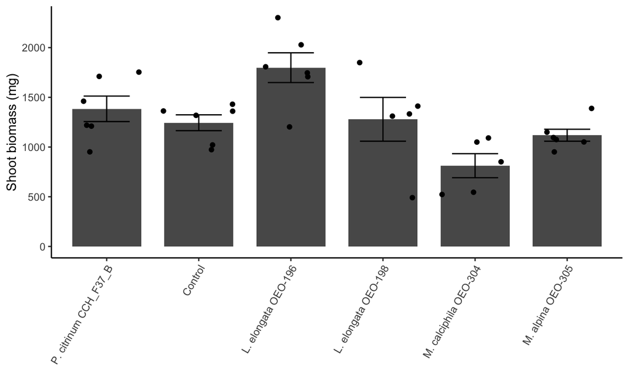

Root biomass

```r
lm.root <- lm(Rootbiomass~ Treatment, data = photosynq_sub)
#plot(lm.root)
summary(lm.root)
```

```
Call:
lm(formula = Rootbiomass ~ Treatment, data = photosynq_sub)

Residuals:
      Min        1Q    Median        3Q       Max
-0.096167 -0.046375  0.002333  0.052042  0.108000

Coefficients:
                 Estimate Std. Error t value Pr(>|t|)
(Intercept)       0.32417    0.02467  13.141  1.7e-13 ***
TreatmentN-F     -0.02383    0.03489  -0.683  0.50012
TreatmentOEO-196  0.03833    0.03489   1.099  0.28122
TreatmentOEO-198 -0.01617    0.03659  -0.442  0.66200
TreatmentOEO-304 -0.12577    0.03659  -3.437  0.00186 **
TreatmentOEO-305 -0.06150    0.03489  -1.763  0.08884 .
---
Signif. codes:  0 ‘***’ 0.001 ‘**’ 0.01 ‘*’ 0.05 ‘.’ 0.1 ‘ ’ 1

Residual standard error: 0.06043 on 28 degrees of freedom
  (171 observations deleted due to missingness)
Multiple R-squared:  0.458, Adjusted R-squared:  0.3612
F-statistic: 4.732 on 5 and 28 DF,  p-value: 0.002943
```

```r
anova(lm.root)
```

```
Analysis of Variance Table

Response: Rootbiomass
          Df   Sum Sq   Mean Sq F value   Pr(>F)
Treatment  5 0.086388 0.0172776  4.7319 0.002943 **
Residuals 28 0.102236 0.0036513
---
Signif. codes:  0 ‘***’ 0.001 ‘**’ 0.01 ‘*’ 0.05 ‘.’ 0.1 ‘ ’ 1
```

```r
lsmeans.root <- emmeans(lm.root, ~ Treatment, adjust = "tukey") # estimate lsmeans

Results_lsmeeans <- cld(object = lsmeans.root,
                        Letters = letters, reversed = TRUE, details = TRUE) # contrast with Tukey ajustment
```

```
Note: adjust = "tukey" was changed to "sidak"
because "tukey" is only appropriate for one set of pairwise comparisons
```

graph

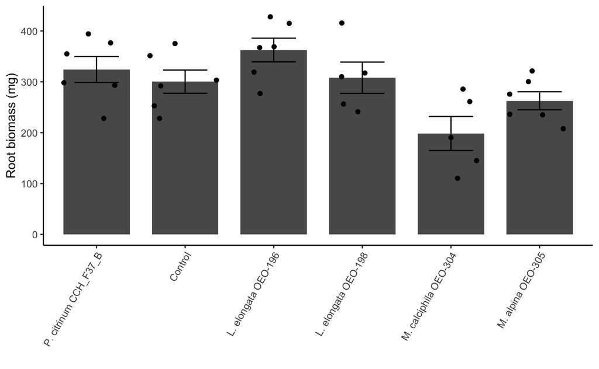

Want to make it pretty? well let’s put both root and shoot fig. together with ggarrange and label them as a) and b) for writing purposes

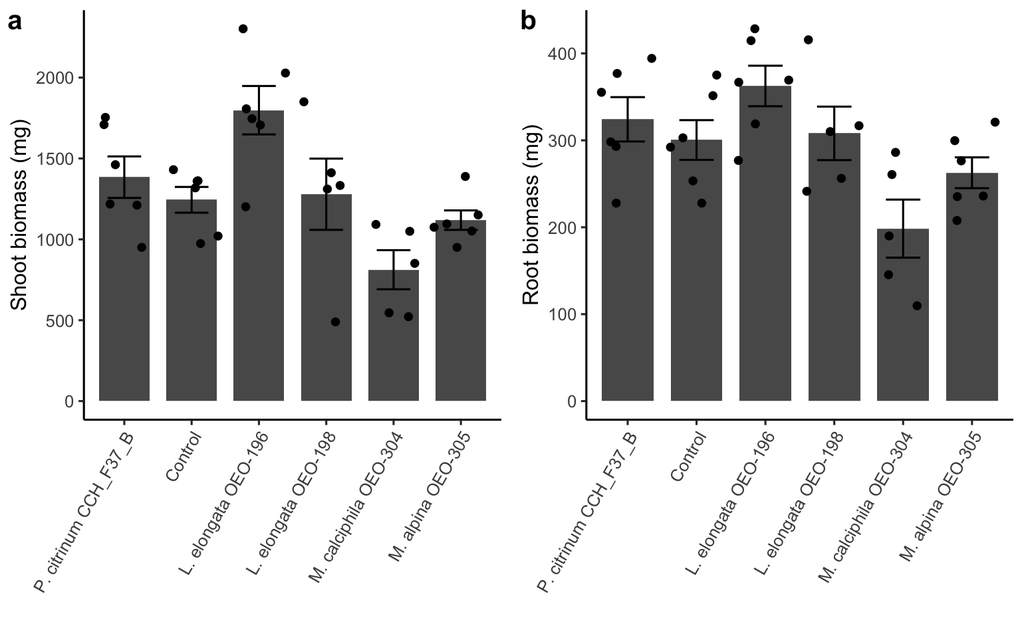

```r
ggarrange(shootbiomass, rootbiomass, labels = c("a", "b"))
```

Now let’s look at the Phi2. Phi2 measures the amount of incoming light that the plant uses for photosynthesis. Here we analyzed the light used for photosynthesis (Phi2) against the days post drought since these measurements were taken throughout the experiment. For the visualization we selected only a few time points

```r
lm.phi2 <- lm(Phi2~ Treatment*as.factor(dayspostdrought), data = photosynq_sub)
#plot(lm.)
summary(lm.phi2)
```

```
Call:
lm(formula = Phi2 ~ Treatment * as.factor(dayspostdrought), data = photosynq_sub)

Residuals:
     Min       1Q   Median       3Q      Max
-0.43260 -0.04717  0.01914  0.06750  0.27767

Coefficients:
                                                Estimate Std. Error t value Pr(>|t|)
(Intercept)                                    0.7248333  0.0508918  14.243   <2e-16 ***
TreatmentN-F                                  -0.0203333  0.0719719  -0.283   0.7779
TreatmentOEO-196                              -0.0956667  0.0719719  -1.329   0.1856
TreatmentOEO-198                              -0.1020333  0.0754848  -1.352   0.1783
TreatmentOEO-304                              -0.0992333  0.0754848  -1.315   0.1904
TreatmentOEO-305                               0.0008333  0.0719719   0.012   0.9908
as.factor(dayspostdrought)2                    0.0076667  0.0719719   0.107   0.9153
as.factor(dayspostdrought)4                   -0.0858333  0.0719719  -1.193   0.2347
as.factor(dayspostdrought)6                   -0.0009762  0.0693539  -0.014   0.9888
as.factor(dayspostdrought)8                   -0.0465000  0.0719719  -0.646   0.5191
as.factor(dayspostdrought)12                   0.0281667  0.0719719   0.391   0.6960
TreatmentN-F:as.factor(dayspostdrought)2       0.0050000  0.1017836   0.049   0.9609
TreatmentOEO-196:as.factor(dayspostdrought)2   0.0236667  0.1017836   0.233   0.8164
TreatmentOEO-198:as.factor(dayspostdrought)2  -0.0358667  0.1067516  -0.336   0.7373
TreatmentOEO-304:as.factor(dayspostdrought)2   0.0649333  0.1067516   0.608   0.5438
TreatmentOEO-305:as.factor(dayspostdrought)2  -0.0260000  0.1017836  -0.255   0.7987
TreatmentN-F:as.factor(dayspostdrought)4       0.0995000  0.1017836   0.978   0.3297
TreatmentOEO-196:as.factor(dayspostdrought)4   0.0848333  0.1017836   0.833   0.4058
TreatmentOEO-198:as.factor(dayspostdrought)4   0.1278333  0.1067516   1.197   0.2328
TreatmentOEO-304:as.factor(dayspostdrought)4   0.1380333  0.1067516   1.293   0.1978
TreatmentOEO-305:as.factor(dayspostdrought)4   0.0713333  0.1017836   0.701   0.4844
TreatmentN-F:as.factor(dayspostdrought)6      -0.0450238  0.0999495  -0.450   0.6530
TreatmentOEO-196:as.factor(dayspostdrought)6  -0.0346905  0.0999495  -0.347   0.7290
TreatmentOEO-198:as.factor(dayspostdrought)6   0.0163762  0.1050043   0.156   0.8763
TreatmentOEO-304:as.factor(dayspostdrought)6   0.0609762  0.1050043   0.581   0.5622
TreatmentOEO-305:as.factor(dayspostdrought)6  -0.0080238  0.0999495  -0.080   0.9361
TreatmentN-F:as.factor(dayspostdrought)8       0.0131667  0.1017836   0.129   0.8972
TreatmentOEO-196:as.factor(dayspostdrought)8   0.0245000  0.1017836   0.241   0.8101
TreatmentOEO-198:as.factor(dayspostdrought)8  -0.0099000  0.1067516  -0.093   0.9262
TreatmentOEO-304:as.factor(dayspostdrought)8   0.1121000  0.1067516   1.050   0.2952
TreatmentOEO-305:as.factor(dayspostdrought)8   0.0146667  0.1017836   0.144   0.8856
TreatmentN-F:as.factor(dayspostdrought)12     -0.2503333  0.1017836  -2.459   0.0149 *
TreatmentOEO-196:as.factor(dayspostdrought)12 -0.1048333  0.1017836  -1.030   0.3045
TreatmentOEO-198:as.factor(dayspostdrought)12 -0.1553667  0.1067516  -1.455   0.1474
TreatmentOEO-304:as.factor(dayspostdrought)12 -0.0223667  0.1067516  -0.210   0.8343
TreatmentOEO-305:as.factor(dayspostdrought)12 -0.1050000  0.1017836  -1.032   0.3037
---
Signif. codes:  0 ‘***’ 0.001 ‘**’ 0.01 ‘*’ 0.05 ‘.’ 0.1 ‘ ’ 1

Residual standard error: 0.1247 on 169 degrees of freedom
Multiple R-squared:  0.2394,    Adjusted R-squared:  0.08192
F-statistic:  1.52 on 35 and 169 DF,  p-value: 0.04278
```

```r
#modified to obtain the pvalue
car::Anova(lm.phi2, test.statistic = "F")
```

```
Anova Table (Type II tests)

Response: Phi2
                                      Sum Sq  Df F value    Pr(>F)
Treatment                            0.35135   5  4.5219 0.0006789 ***
as.factor(dayspostdrought)           0.18447   5  2.3741 0.0411291 *
Treatment:as.factor(dayspostdrought) 0.28981  25  0.7460 0.8033613
Residuals                            2.62624 169
---
Signif. codes:  0 ‘***’ 0.001 ‘**’ 0.01 ‘*’ 0.05 ‘.’ 0.1 ‘ ’ 1
```

```r
anova(lm.phi2)
```

```
Analysis of Variance Table

Response: Phi2
                                      Df  Sum Sq  Mean Sq F value    Pr(>F)
Treatment                              5 0.35249 0.070499  4.5367 0.0006597 ***
as.factor(dayspostdrought)             5 0.18447 0.036893  2.3741 0.0411291 *
Treatment:as.factor(dayspostdrought)  25 0.28981 0.011593  0.7460 0.8033613
Residuals                            169 2.62624 0.015540
---
Signif. codes:  0 ‘***’ 0.001 ‘**’ 0.01 ‘*’ 0.05 ‘.’ 0.1 ‘ ’ 1
```

```r
lsmeans.phi2 <- emmeans(lm.phi2, ~ Treatment|dayspostdrought, adjust = "tukey") # estimate lsmeans

Results_lsmeeans <- cld(object = lsmeans.phi2,
                        Letters = letters, reversed = TRUE, details = TRUE) # contrast with Tukey ajustment
```

```
Note: adjust = "tukey" was changed to "sidak"
because "tukey" is only appropriate for one set of pairwise comparisons
```

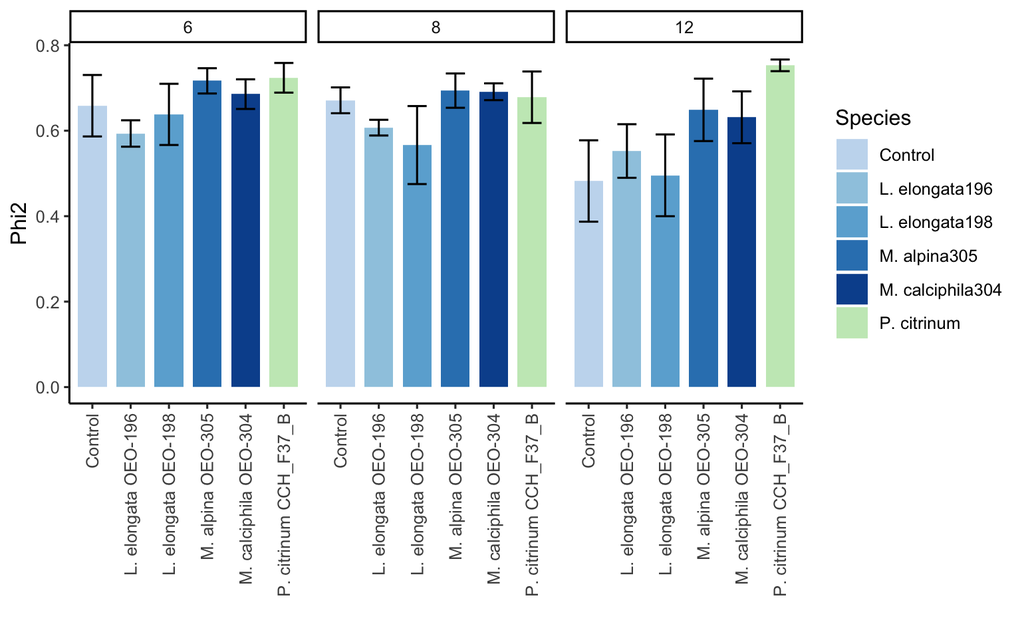

```r
#Graph
photosynq_sub %>%
  subset(dayspostdrought %in% c(6:12)) %>%
  ggplot(aes(x = Species, y = Phi2, fill = Species)) +
  stat_summary(fun.y=mean,geom="bar", width = 0.75, position = "dodge") +
  stat_summary(fun.data = mean_se, geom = "errorbar", width = 0.5, position = "dodge") +
  scale_fill_manual(values=fungi.colors) +
  ##keep and aye for this command; it only substitute the label it does not means that is the correct label for the bar.
  scale_x_discrete(labels = c("Control", "L. elongata OEO-196", "L. elongata OEO-198",
                              "M. alpina OEO-305", "M. calciphila OEO-304","P. citrinum CCH_F37_B")) +
  ylab("Phi2") +
  xlab("") +
  facet_wrap(~dayspostdrought)+
  theme_classic() +
  theme(axis.text.x = element_text(angle = 90, vjust = 0.5, hjust=1))
```